# Task 2

Collect all the paper info on the Stack Overflow dataset (you can get a list from here: https://meta.stackexchange.com/questions/134495/academic-papers-using-stack-exchange-data). The title would be fine that you can scrape. Clusters the papers (find a way to group similar paper together) and present the result on a webpage.

## To solve this problem, I need to scrape the data first. I used BeautifulSoup library to scrape the data and used KMeans algorithm for clustering the data.

# Import Libraries

```python
import requests
import pandas as pd
from bs4 import BeautifulSoup
import numpy as np
import nltk
import pandas as pd
import regex as re
import string
from nltk.corpus import stopwords
from nltk.tokenize import word_tokenize
from nltk.stem import WordNetLemmatizer
from wordcloud import WordCloud
import matplotlib.pyplot as plt
from sklearn.feature_extraction.text import TfidfVectorizer
from sklearn.cluster import KMeans
from sklearn.metrics import silhouette_score
import seaborn as sns
```

# Data Collection

At first, we will scrape the data. The following function will return the paper information as a DataFrame.

```python
# This function will scrape all of the paper's information.
# Return: It will return a dataframe of three columns.
# Each row contains the information of each paper.
# First column contains the author's information of paper.
# Second column contains the paper title.
# Third column contains the proceddings informations.
def get_papers_info():
    page = requests.get("https://meta.stackexchange.com/questions/134495/academic-papers-using-stack-exchange-data")
    soup = BeautifulSoup(page.content, 'html.parser')
    # Parse all answers from the page
    answers = soup.find(id='answers')
    # Find all <li> tag from each of the answers
    paper_lists = answers.find_all('li')
    # Remove all <a> tag from the <li>
    for paper in paper_lists:
        a = paper.find_all('a')
        for x in a:
            x.extract()
    # Remove <li> tag from each element
    final_refined_data = [li.find('p') for li in paper_lists if li.find('p')]
    # Extract authors, paper title and proceddings for each papers
    paper_titles, authors_list, proceedings = [], [], []
    full_data = []
    for p in final_refined_data:
        full_doc = p.get_text()
        paper_title = p.find('strong').get_text()
        authors_proceding = full_doc.split(paper_title)
        paper_titles.append(paper_title.replace('\n', ''))
        authors_list.append(authors_proceding[0].replace('\n', ''))
        proceedings.append(authors_proceding[1].replace('\n', '').strip('.').strip(','))
    # Convert the result into DataFrame.
    df = pd.DataFrame({'authors': authors_list, 'title': paper_titles, 'proceedings': proceedings})
    return df
```

```python
df = get_papers_info()
```

Lets print the information of first 5 papers.

```python
df.head(5)
```

|  | authors | title | proceedings |
| --- | --- | --- | --- |
| 0 | Rodrigo Silva, Chanchal Roy, Masud Rahman, Kev... | CROKAGE: Effective Solution Recommendations fo... | Empirical Software Engineering, 25, 4707–4758. |
| 1 | Preetha Chatterjee, Minji Kong, Lori Pollock. | Finding help with programming errors: An explo... | Journal of Systems and Software, Volume 159, 2020 |
| 2 | Saikat Mondal, Gias Uddin, and Chanchal K. Roy. | Automatic Identification of Rollback Edit with... | 36th International Conference on Software Mai... |
| 3 | Timur Bachschi, Aniko Hannak, Florian Lemmeric... | From Asking to Answering: Getting More Involve... | arXiv preprint: 2010.04025, 2020. |
| 4 | Sebastian Baltes, Christoph Treude, and Martin... | Contextual Documentation Referencing on Stack ... | IEEE Transactions on Software Engineering (TS... |

### Lets use the paper titles and the topics of proceedings for clustering the data.

# Preprocess the data

At first, we are going to preprocess the paper titles and porceedings. Later we will use the paper title and proceedings for clustering.

After going through the data, I have found that q&a exists in the data several times. And also 'question answering' phrase exists in the data multiple times. So lets convert 'q&a' into 'question answering'. As the prepositions and articles are not significant to cluster the data, lets remove them.

```python
# This function will preprocess the paper title.
# Will return the preprocessed title
def clear_title(da):
  # Convert all the character to lower case
    da = da.lower()
    # After going through the data, I have found
    # that q&a exists in the data several time. and
    # question answering phrase also exists in the
    # data. So lets convert q&a to question answering
    da = da.replace('q&a', 'question Answering')
    da = da.replace('q/a', 'question Answering')
    # Remove all the characters accept alphabet and numbers.
    final_data = re.sub(r'[^a-zA-Z0-9]',' ', da)
    # remove some stop words:
    final_data = ' ' + final_data + ' '
    stop = [
        ' on ',
        ' of ',
        ' the ',
        ' and ',
        ' in ',
        ' for ',
        ' to ',
        ' with ',
        ' an ',
    ]
    for st in stop:
        final_data = final_data.replace(st, ' ')
    return final_data.strip()
```

To get the proceeding's topics, we will split the proceedings by 'on' key and take the second part. For exampple, lets consider the following proceeding:

`Proceedings of the 16th International Conference on Mining Software Repositories`

After splitting this by ' on ', we will consider the second part as the proceedings topics:

1. **First part:** `Proceedings of the 16th International Conference`
2. **Second part:** `Mining Software Repositories`

```python
# This function will preprocess the proceedings to extract the topics.
def clear_proceedings(da):
    da = da.lower()
    da = da.split(' on ')
    if len(da) <= 1:
        return ''
    da = da[1].split('(')[0]
    da = re.sub(r'[^a-zA-Z0-9]',' ', da)
    da = re.split(' acm | ieee | acl | icpc | springer ', da)[0]
    da = re.split(' pages | volume | vol  ', da)[0]
    da = ' ' + da + ' '
    stop = [
      ' on ',
      ' of ',
      ' the ',
      ' and ',
      ' in ',
      ' for ',
      ' to ',
      ' with ',
      ' from '
      ' an ',
    ]
    for st in stop:
        da = da.replace(st, ' ')
    da = da.strip()
    return da
```

```python
df['processed_title'] = df['title'].map(clear_title)
df['topics'] = df['proceedings'].map(clear_proceedings)
```

Finally, we will make the final data by the concatenation of the title and topics of the proceedings.

```python
df['data'] = df['processed_title'] + ' on ' + df['topics']
```

```python
list(df['data'].head(5))
```

```
['crokage  effective solution recommendations programming tasks by leveraging crowd knowledge on ',
 'finding help programming errors  exploratory study novice software engineers  focus stack overflow posts on ',
 'automatic identification rollback edit reasons stack overflow question Answering site on software maintenance evolution',
 'from asking answering  getting more involved stack overflow on ',
 'contextual documentation referencing stack overflow on software engineering']
```

### Lets, see the word's orientation across the dataset. We will use the wordcloud package for this purpose.

```python
nltk.download('stopwords')
stops = set(stopwords.words("english"))
```

```python
# this function will show the word's cloud of list of sentences
def show_word_cloud(data_list):
  data_as_string = ' '.join(data_list)
  wordcloud = WordCloud(width = 800, height = 800,
                  background_color ='white',
                  stopwords = stops,
                  min_font_size = 10).generate(data_as_string)

  # plot the WordCloud image
  plt.figure(figsize = (8, 8), facecolor = None)
  plt.imshow(wordcloud)
  plt.axis("off")
  plt.tight_layout(pad = 0)
  plt.show()
```

Lets, see the word cloud of the data.

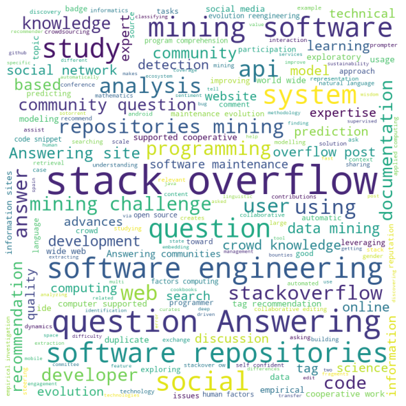

```python
show_word_cloud(df['data'])
```

# Clustering

For clustering, we are going to implement the KMeans algorithm. At first, we will extract features using TfIdfvectorizer.

### Feature extraction

```python
tfidf_vectorizer = TfidfVectorizer()
tfidf = tfidf_vectorizer.fit_transform(df['data'])
```

### Train the KMeans clustering model

```python
# This function will return the k clusters of the data
def kmeans(k):
    km = KMeans(
        n_clusters = k
        , init = 'k-means++'
        , n_init = 10
        , tol = 0.0001
        , n_jobs = -1
        , random_state = 1
        , algorithm = 'full'
    )
    km = km.fit(tfidf)
    return km
```

### Find the best k for KMeans

As we don't know the number of cuslters(k) among the data, we need to find out the number of clusters(k) of the data. Here, we will use two metrics to assump the best k for our data.

- **The Elbow Method**: Calculate the Within-Cluster-Sum of Squared Errors (WSS) for different values of k, and choose the k for which WSS becomes first starts to diminish. In the plot of WSS-versus-k, this is visible as an elbow.
- **The Silhouette Method**: The silhouette value measures how similar a point is to its own cluster (cohesion) compared to other clusters (separation).

Lets run the KMeans for k = 2 to k = 10.

```python
kms = []
K = range(2, 11)
for k in K:
    km = kmeans(k)
    km = km.fit(tfidf)
    kms.append(km)
```

Now we will calculate the data for Elbow and Silhouette metrics.

```python
sum_of_squared_distances, silhouette_scores = [], []
for km in kms:
    sum_of_squared_distances.append(km.inertia_)
    labels = km.labels_
    silhouette_scores.append(silhouette_score(tfidf, labels, metric = 'euclidean'))
```

Now, Lets plot WSS-versus-k and silhouette_score-versus-k.

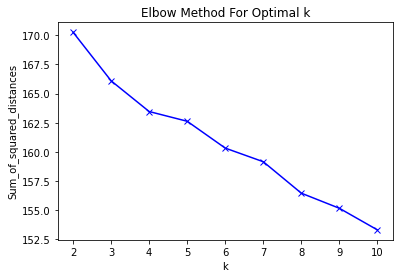

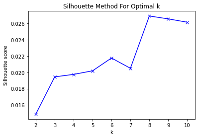

```python
plt.plot(K, sum_of_squared_distances, 'bx-')
plt.xlabel('k')
plt.ylabel('Sum_of_squared_distances')
plt.title('Elbow Method For Optimal k')
plt.show()

plt.plot(K, silhouette_scores, 'bx-')
plt.xlabel('k')
plt.ylabel('Silhouette score')
plt.title('Silhouette Method For Optimal k')
plt.show()
```

Now, we can take a deeper look at each cluster and choose the best k. Though the graphs have lot of fluctuations, we can select 6 or 8 as k for the custering. Lets select 6 as the total number of clusters.

```python
# Select the cluster with k = 4
num_of_clusters = 6
cluster = kms[num_of_clusters - 2]
# Add cluster number as labels columns
df['labels'] = cluster.labels_
```

```python
df.head(5)
```

|  | authors | title | proceedings | processed_title | topics | data | labels |
| --- | --- | --- | --- | --- | --- | --- | --- |
| 0 | Rodrigo Silva, Chanchal Roy, Masud Rahman, Kev... | CROKAGE: Effective Solution Recommendations fo... | Empirical Software Engineering, 25, 4707–4758. | crokage effective solution recommendations pr... |  | crokage effective solution recommendations pr... | 3 |
| 1 | Preetha Chatterjee, Minji Kong, Lori Pollock. | Finding help with programming errors: An explo... | Journal of Systems and Software, Volume 159, 2020 | finding help programming errors exploratory s... |  | finding help programming errors exploratory s... | 2 |
| 2 | Saikat Mondal, Gias Uddin, and Chanchal K. Roy. | Automatic Identification of Rollback Edit with... | 36th International Conference on Software Mai... | automatic identification rollback edit reasons... | software maintenance evolution | automatic identification rollback edit reasons... | 4 |
| 3 | Timur Bachschi, Aniko Hannak, Florian Lemmeric... | From Asking to Answering: Getting More Involve... | arXiv preprint: 2010.04025, 2020. | from asking answering getting more involved s... |  | from asking answering getting more involved s... | 2 |
| 4 | Sebastian Baltes, Christoph Treude, and Martin... | Contextual Documentation Referencing on Stack ... | IEEE Transactions on Software Engineering (TS... | contextual documentation referencing stack ove... | software engineering | contextual documentation referencing stack ove... | 5 |

# Result Analysis

So now, lets show the paper titles of each cluster.

```python
for i in range(num_of_clusters):
    cluster_i = df[df['labels'] == i]
    print('Papers of cluster: {}'.format(i + 1))
    for j, paper in enumerate(cluster_i.values):
        print('Cluster {}, Paper {} => {}{}, {}\n'.format(i + 1, j + 1, paper[0], paper[1], paper[2]))
    print('........................................')
```

```
Papers of cluster: 1
Cluster 1, Paper 1 => Agnieszka Geras, Grzegorz Siudem, Marek Gagolewski. Should we introduce a dislike button for academic articles?,  Journal of the Association for Information Science and Technology (JASIST) 71.2 (2020), pp. 221–229.

Cluster 1, Paper 2 => Zakaria Mehrab, Raquib Bin Yousuf, Ibrahim Asadullah Tahmid, Rifat Shahriyar. Mining Developer Questions about Major Web Frameworks,  Proceedings of the 14th International Conference on Web Information Systems and Technologies - Volume 1: WEBIST, 191-198, 2018.

Cluster 1, Paper 3 => Campbell, Brock Angus, and Christoph Treude. NLP2Code: Code Snippet Content Assist via Natural Language Tasks.,  arXiv preprint arXiv:1701.05648 (2017)

Cluster 1, Paper 4 => Vinayakarao, Venkatesh, et al. Anne: Improving source code search using entity retrieval approach.,  Proceedings of the Tenth ACM International Conference on Web Search and Data Mining. ACM, 2017.

Cluster 1, Paper 5 => Boudaer, Glenn, and Johan Loeckx. Enriching Topic Modelling with Users' Histories for Improving Tag Prediction in Q&A Systems.,  Proceedings of the 25th International Conference Companion on World Wide Web. International World Wide Web Conferences Steering Committee, 2016

Cluster 1, Paper 6 => Utkarsh Upadhyay, Isabel Valera, Manuel Gomez-Rodriguez. Uncovering the Dynamics of Crowdlearning and the Value of Knowledge,  10th ACM International Conference on Web Search and Data Mining Conference (WSDM 2016). (Submitted on 14 Dec 2016.)

Cluster 1, Paper 7 => Eduardo Campos, Lucas Souza, Marcelo Maia. Searching Crowd Knowledge to Recommend Solutions for API Usage Tasks,  Journal of Software: Evolution and Process (JSEP). (Volume: 28, Issue: 10, Pages: 863--892). Wiley, 2016

Cluster 1, Paper 8 => Manish Bhanu, Joydeep Chandra.Exploiting response patterns for identifying topical experts in StackOverflow., Eleventh International Conference on Digital Information Management (ICDIM 2016)

Cluster 1, Paper 9 => Luis Mastrangelo, Luca Ponzanelli, Andrea Mocci, Matthias Hauswirth, Nathaniel Nystrom, Michele Lanza. Use at Your Own Risk: The Java Unsafe API in the Wild,  In Proceedings of the International Conference on Object Oriented Programming Systems Languages & Applications (OOPSLA …

Cluster 1, Paper 10 => Luca Ponzanelli, Gabriele Bavota, Massimiliano Di Penta, Rocco Oliveto, Michele Lanza. Prompter: Turning the IDE into a Self-confident Programming Assistant,  Empirical Software Engineering (EMSE)

Cluster 1, Paper 11 => Arwan Achmad, Rochimah Siti, Akbar Rizky, January 2015. Source code retrieval on StackOverflow using LDA,  In: Information and Communication Technology (ICoICT), 2015 3rd International Conference on. IEEE, 2015. p. 295-299.

Cluster 1, Paper 12 => Samuel Maurus and Claudia Plant, 2014. Ternary Matrix Factorization,  In IEEE International Conference on Data Mining, 2014 (ICDM 2014)

Cluster 1, Paper 13 => G. Gkotsis, K. Stepanyan, C. Pedrinaci, J. Domingue, and M. Liakata. 2014.It’s all in the content: State of the art best answer prediction based on discretisation of shallow linguistic features,  In 2014 ACM Conference on Web Science (WebSci ’14). ACM

Cluster 1, Paper 14 => Alexander Halavais, K Hazel Kwon, Shannon Havener and Jason Striker. 2014.Badges of Friendship: Social Influence and Badge Acquisition on Stack Overflow, In 47th Hawaii International International Conference on Systems Science (HICSS-47 2014).IEEE

Cluster 1, Paper 15 => Sangeeta Lal, Denzil Correa, and Ashish Sureka. 2014.MiQs: Characterization and Prediction of Migrated Questions on StackExchange, In 21st Asia-Pacific Software Engineering Conference (APSEC 2014)

Cluster 1, Paper 16 => Dana Movshovitz-Attias and William Cohen, 2013.Natural Language Models for Predicting Programming Comments, In Proceedings of the Association for Computational LinguisticsACL

Cluster 1, Paper 17 => Priyanka Singh, Nigel Shadbolt, 2013.Linked data in crowdsourcing purposive social network.,  In WWW (Companion Volume) International World Wide Web Conferences Steering Committee, pages 913-918

Cluster 1, Paper 18 => Alexandru Lucian Ginsca, Adrian Popescu, 2013.User profiling for answer quality assessment in Q&A communities, In Proceedings of the 2013 workshop on Data-driven user behavioral modelling and mining from social mediaACM, pages 25-28

Cluster 1, Paper 19 => Rahul Venkataramani, Atul Gupta, Allahbaksh M. Asadullah, Basavaraju Muddu, Vasudev D. Bhat, 2013.Discovery of technical expertise from open source code repositories, In Proceedings of the 22nd international conference on World Wide Web companionInternational World Wide Web Co…

Cluster 1, Paper 20 => David Kavaler, Daryl Posnett, Clint Gibler, Hao Chen, Premkumar Devanbu, Vladimir Filkov, 2013.Using and Asking: APIs Used in the Android Market and Asked about in StackOverflow, In Social Informatics.Springer Verlag, Lecture Notes in Computer Science Volume 8238, 2013, pp 405…
```

[output cut: 323 more lines]

```
Cluster 6, Paper 34 => Bogdan Vasilescu, Alexander Serebrenik, Mark G.J. van den Brand. 2013. The Babel of software development: Linguistic diversity in Open Source, In 5th International Conference on Social Informatics.Springer LNCS 8238, pages 391-404

Cluster 6, Paper 35 => Luca Ponzanelli, Alberto Bacchelli and Michele Lanza. 2013.Seahawk: Stack Overflow in the IDE,  In 2013 International Conference on Software Engineering.IEEE, pages 1295-1298

Cluster 6, Paper 36 => Alberto Bacchelli, Luca Ponzanelli and Michele Lanza. 2012. Harnessing Stack Overflow for the IDE,  In 2012 Third International Workshop on Recommendation Systems for Software Engineering (RSSE).IEEE, pages 26-30

Cluster 6, Paper 37 => Alexey Zagalsky, Ohad Barzilay, and Amiram Yehudai. 2012. Example overflow: Using social media for code recommendation,  In Third International Workshop on Recommendation Systems for Software Engineering (RSSE 2012).IEEE, pages 38-42

Cluster 6, Paper 38 => Chris Parnin, and Christoph Treude. Measuring API documentation on the web,  2011. In 2nd International Workshop on Web 2.0 for Software Engineering (Web2SE’11), ACM, pages 25–30

Cluster 6, Paper 39 => Christoph Treude, Ohad Barzilay, and Margaret-Anne D. Storey. 2011. How do programmers ask and answer questions on the web?: NIER track,  In 33rd International Conference on Software Engineering (ICSE'11), IEEE, pages 804-807

Cluster 6, Paper 40 => Barthélémy Dagenais and Martin P. Robillard. 2010, Creating and evolving developer documentation: understanding the decisions of open source contributors,  In 18th ACM SIGSOFT International Symposium on Foundations of Software Engineering (FSE '10), ACM, pages 127-136

........................................
```

Lets see the word cloud of the clusters

```
Word cloud of cluster: 1
```

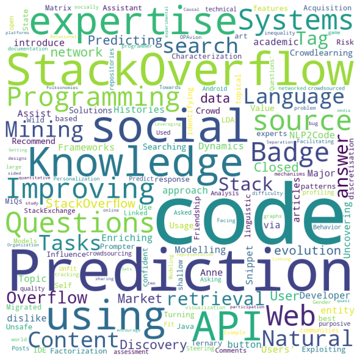

```
Word cloud of cluster: 2
```

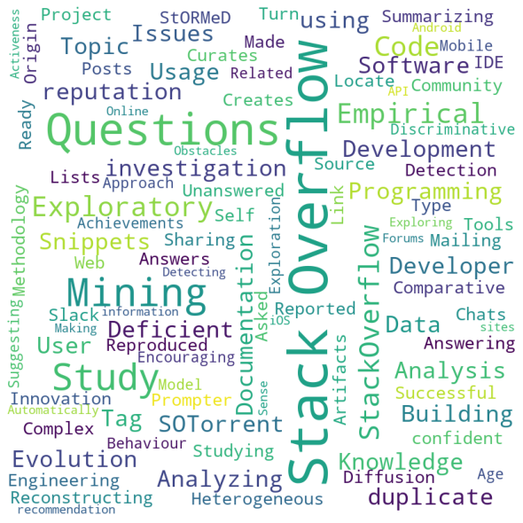

```
Word cloud of cluster: 3
```

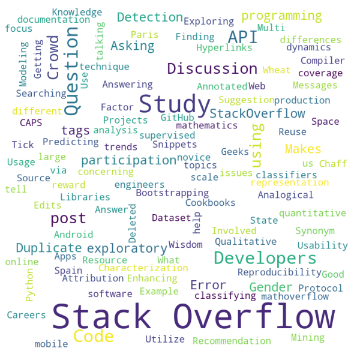

```
Word cloud of cluster: 4
```

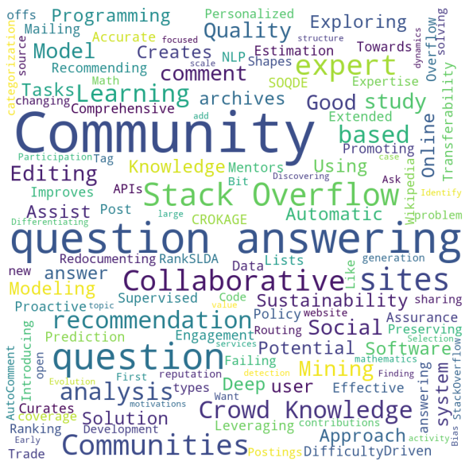

```
Word cloud of cluster: 5
```

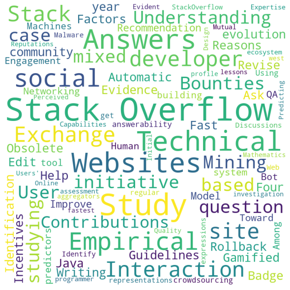

```
Word cloud of cluster: 6
```

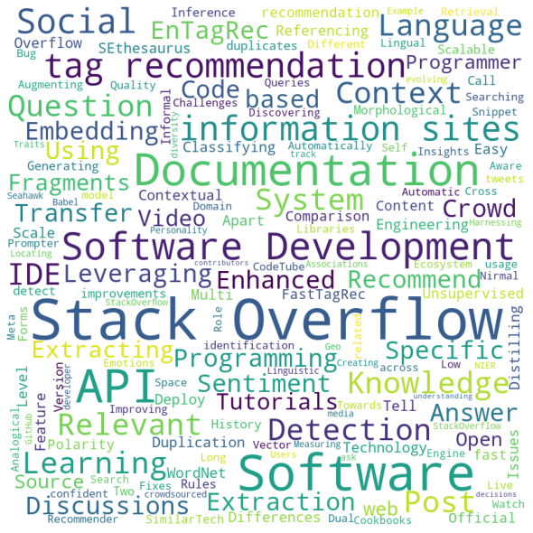

```python
for i in range(num_of_clusters):
    cluster_i = df[df['labels'] == i]
    print('Word cloud of cluster: {}'.format(i + 1))
    sentences = list(cluster_i['title'])
    show_word_cloud(sentences)
```

Lets, draw a simple histogram for each cluster to show the most dominant words from each clusters.

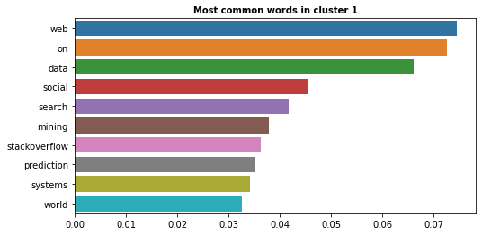

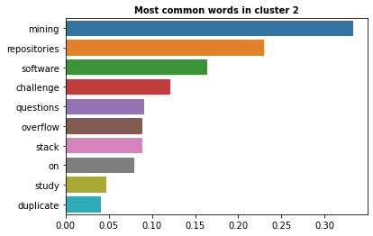

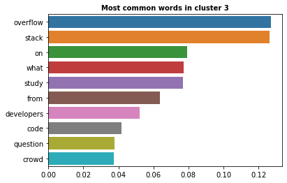

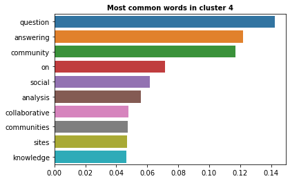

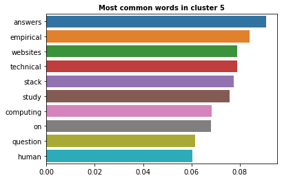

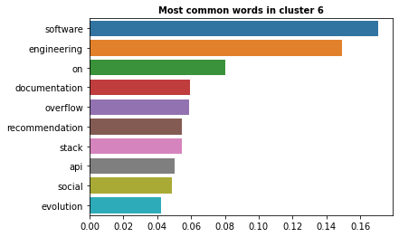

```python
plt.figure(figsize=(8, 4))
for i in range(num_of_clusters):
    cluster_i = np.array(df['labels'].to_numpy())
    idx = np.where(cluster_i == i)
    x_means = np.mean(tfidf[idx].toarray(), axis = 0)
    sorted_means = np.argsort(x_means)[::-1][:10]
    features = tfidf_vectorizer.get_feature_names()
    best_features = [features[i] for i in sorted_means]
    features_scores = [x_means[i] for i in sorted_means]
    plt.title(("Most common words in cluster {}".format(i + 1)), fontsize=10, fontweight='bold')
    sns.barplot(x = features_scores , y = best_features, orient = 'h')
    plt.show()
```